# Utah

850

29%

5

People In Prison Past  
Parole Eligibility*  
(2023 Projection TBD)

Prison Population Incarcerated  
Past Parole Eligibility  
(2023 Projection TBD)

Parole Board  
Members

*Only includes people in prison for new offenses and excludes people with life sentences and sentences less than one year.

**Parole Eligibility**

## How Parole Eligibility Is Determined

Parole eligibility refers to the point in a person’s prison sentence when they become eligible for consideration for release under parole. Parole is a conditional release, allowing the person to serve the remainder of their sentence in the community under supervision, rather than in prison.

In Utah, sentencing judges have no discretion to set or influence the actual durations of the prison sentences they impose for each crime. “Judicial” maximum prison sentences must be fixed at the same level as the statutory maximum penalty for the offense of conviction. Any applicable minimum terms to parole-release eligibility are also preset by statute. Parole release dates are determined by the parole board.¹

## In Prison Past Parole Eligibility

In 2019, 29 percent of people in prison were currently past their parole eligibility. Another 71 percent will reach their parole eligibility after 2019.

[interactive chart not shown]

From 2010 to 2020, the percent of people in prison past parole eligibility increased by 22 percent.

[interactive chart not shown]

## Demographics

**Race and Ethnicity**

In 2019, 66 percent of people in prison past parole eligibility were White, non-Hispanic.

[interactive chart not shown]

**Sex**

In 2019, 91 percent of people in prison past parole eligibility were male.

[interactive chart not shown]

**Age**

In 2019, 33 percent of people in prison past parole eligibility were between the ages of 35 and 44 years old.

[interactive chart not shown]

## Offense Types

In 2019, 71 percent of people in prison past parole eligibility were in prison for violent offenses and 29 percent for nonviolent offenses. Most people who were incarcerated past parole eligibility were serving time for rape or sexual assault (33 percent) offenses.

[interactive chart not shown]

## Sentence Lengths

In 2019, 64 percent of people in prison past parole eligibility had sentence lengths between 10 and 24.9 years.

[interactive chart not shown]

## Endnotes

¹ Kevin R. Reitz, Allegra Lukac, and Edward E. Rhine, *Prison-Release Discretion and Prison Population Size: State Report: Utah* (Robina Institute of Criminal Law and Criminal Justice, October 2021), https://robinainstitute.umn.edu/sites/robinainstitute.umn.edu/files/2023-03/utah_doi_report_10_12_21.pdf.  
² US Bureau of Justice Statistics., “National Corrections Reporting Program NCRP Series” (Inter-university Consortium for Political and Social Research, 2022), accessed October 2, 2024, https://www.icpsr.umich.edu/web/NACJD/series/38.  
³ Kevin Reitz et al., American Prison-Release Systems: Indeterminacy in Sentencing and the Control of Prison Population Size, Final Report (Minneapolis, Minnesota: Robina Institute, University of Minnesota, 2022), accessed October 1, 2024, https://robinainstitute.umn.edu/sites/robinainstitute.umn.edu/files/2022-05/american_prison-release_systems.pdf, 36-43.  
⁴ US Bureau of Justice Statistics, “National Prisoner Statistics, 1978-2022” (Inter-university Consortium for Political and Social Research), accessed January 10, 2024, https://doi.org/10.3886/ICPSR38871.v1.“Utah Department of Corrections Dashboard – UDC Average Yearly Incarcerated Population,” Utah Department of Corrections, accessed October 1, 2024, https://corrections.utah.gov/operations-dashboard/.

Data analysis was conducted using information from the National Corrections Reporting Program and the National Prisoner Statistics Program. See “National Corrections Reporting Program (NCRP),” Bureau of Justice Statistics, accessed September 25, 2024, https://bjs.ojp.gov/data-collection/national-corrections-reporting-program-ncrp; “Prisoners - Statistical Tables,” Bureau of Justice Statistics, accessed September 25, 2024, https://bjs.ojp.gov/library/publications/list?series_filter=Prisoners.

**Prison Population**

## Prison Population Trends

From 2010 to 2022, the prison population decreased 13 percent, changing from 6,807 in 2010 to 5,911 in 2022.

[interactive chart not shown]

## Demographics

**Race and Ethnicity**

In 2019, 61 percent of people in prison were White, non-Hispanic.

[interactive chart not shown]

**Sex**

In 2019, 91 percent of people in prison were male.

[interactive chart not shown]

**Age**

In 2019, 32 percent of people in prison were between the ages of 35 and 44 years old.

[interactive chart not shown]

## Offense Types

In 2019, 27 percent of people in prison were incarcerated for rape or sexual assault offenses.

[interactive chart not shown]

## Sentence Lengths

In 2019, 36 percent of people in prison had sentence lengths between 10 and 24.9 years.

[interactive chart not shown]

**Prison Releases**

## Prison Release Trends

[interactive chart not shown]

In 2020, 55 percent of parole-eligible people released in Utah were released past their parole eligibility year, which is an increase of 28 percent from 2010.

[interactive chart not shown]

## Conditional Releases

Conditional release involves an individual’s release under specific conditions and supervision, whereas unconditional release means the individual is released without further obligations or restrictions. In 2019, 79 percent of people released from prison were conditional releases.

[interactive chart not shown]

## Demographics

**Race and Ethnicity**

In 2019, 69 percent of people released from prison were White, non-Hispanic.

[interactive chart not shown]

**Sex**

In 2019, 83 percent of people released from prison were male.

[interactive chart not shown]

**Age**

In 2019, 35 percent of people released from prison were 25-34 years.

[interactive chart not shown]

## Offense Types

In 2019, 27 percent of people released from prison were incarcerated for drug offenses.

[interactive chart not shown]

**Disparities**

## Disparities in Parole Release

**Race and Ethnicity**

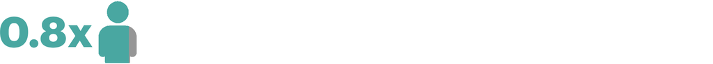

In 2019, Black people were 20 percent less likely to be incarcerated in state prison past parole eligibility than White people, when accounting for population sizes in Utah.

**Sex**

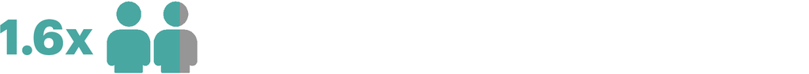

In 2019, males were incarcerated in state prison past parole eligibility at a rate 1.6 times higher than females, when accounting for prison population sizes in Utah.

## Years in Prison Past Parole Eligibility

**Race and Ethnicity**

In 2019, Black people who were still incarcerated spent on average 0.2 less years past parole eligibility, and Hispanic people who were still incarcerated spent on average 0.3 less years past parole eligibility compared to White people.

Average Years in Prison Past Parole Eligibility

3.4 Years

3.3 Years

3.6 Years

Black

Hispanic

White

The chart below shows the average time spent in prison past parole eligibility by offense type and race and ethnicity in 2020. The largest disparity was observed among murder or nonnegligent manslaughter offenses, where Hispanic people spent on average 1.4 more years in prison compared to White people.

[interactive chart not shown]

**Sex**

In 2019, females who were still incarcerated spent on average 1.8 more years past parole eligibility compared to males in Utah.

Average Years in Prison Past Parole Eligibility

3.5 Years

5.3 Years

Male

Female

The chart below shows the average time spent in prison past parole eligibility by offense type and sex in 2020. The largest disparity was observed among public order offenses, where males spent on average 2.5 more years in prison compared to females.

[interactive chart not shown]

## Time Served

**Race and Ethnicity**

In 2019, Black people released spent on average 0.2 more years in prison compared to White people.

[interactive chart not shown]

The chart below shows the average time served in prison by offense type and race and ethnicity in 2020. The largest disparity was observed among property offenses, where Black people spent on average 0.7 more years in prison compared to White people.

[interactive chart not shown]

**Sex**

In 2019, females released spent on average 0.9 less years in prison compared to males in Utah.

[interactive chart not shown]

The chart below shows the average time served in prison by offense type and sex in 2020. The largest disparity was observed among murder or nonnegligent manslaughter offenses, where males spent on average 9.8 more years in prison compared to females.

[interactive chart not shown]

## Notes on Disparities

**Understanding Disparities in Parole Outcomes**

In examining disparities in parole release rates, this analysis uses the Relative Rate Index (RRI) as a metric to assess differences in criminal justice outcomes—including incarceration rates, parole eligibility, and time served—across race, ethnicity, and sex.

The RRI is calculated by dividing the rate for Black or Hispanic individuals by the rate for White individuals, with values above 1.0 indicating that a group experiences the outcome at a higher rate relative to White individuals, and values below 1.0 indicating a lower rate. This allows for a comparative analysis of which groups are more likely to remain incarcerated past their parole eligibility.

**Metrics Displayed in Visualizations**

Our visualizations present three main metrics to highlight disparities across race, ethnicity, and sex:

- **RRI of Parole Release:** This metric compares the proportion of individuals past parole eligibility within the total prison population by race, ethnicity, and sex. It provides a snapshot of who remains in prison despite being eligible for parole.
- **Average Time Past Parole Eligibility:** For those individuals who remain incarcerated past their parole eligibility date, we show the average additional time spent in prison. This is broken down by race, ethnicity, and sex, highlighting the length of delay in parole release among different groups.
- **Average Total Time Served:** We also display the average total time served in prison by race, ethnicity, and sex, providing insight into sentencing and incarceration length disparities.

**Data Considerations** Our analysis focuses on Black, Hispanic, and White categories to align with data limitations from the National Corrections Reporting Program (NCRP), which categorizes individuals as White, Black, Hispanic, or Other. The term “Hispanic” is used here to align with NCRP terminology.

Data collection and reporting practices vary significantly across states:

- Race and Ethnicity Identification: Some states collect race and ethnicity data based on intake officers’ assessments, while others allow individuals to self-identify. This may result in variability and influence RRI calculations.
- Combined vs. Separate Categories: Some states combine race and ethnicity into a single category, while others separate them. This inconsistency can impact the accuracy and comparability of data, sometimes leading to an underreporting of Hispanic individuals and mixed-race individuals or an overrepresentation of non-Hispanic White individuals.

**Small Sample Sizes and Interpretation**

Interpret findings with small numbers cautiously, as they may introduce variability and yield less reliable estimates. We exclude individuals categorized as “Other race(s), non-Hispanic” because the small numbers in this group limit the ability to make meaningful comparisons. According to NCRP, the “Other race(s)” category may include American Indian or Alaska Native, Asian, Native Hawaiian or Other Pacific Islander, and individuals identifying as more than one race. Small sample sizes can produce unreliable or potentially misleading results in disparities analysis.